# SalesAnalysis

## Black Friday - Sales Analysis

Top Insights from Black Friday sales report, shared in [Kaggle](https://www.kaggle.com/mehdidag/black-friday).

With this data, I will try to answer the following questions

1. What all are the products, that have been purchased the most?
2. Which product category has been sold the maximum?
3. Men or Women, who are likely to spend more in Black Friday Sales?
4. Married or Individuals, who spends more?
5. Which age group has more interest in these type of sales?

# 1 Quick Insights about the EDA

```python
#import packages
import pandas as pd
import numpy as np
import matplotlib.pyplot as plt
from matplotlib.legend_handler import HandlerBase
from matplotlib.text import Text
import seaborn as sns
%matplotlib inline
```

```python
#load the dataset
df = pd.read_csv("./Data/BlackFriday.csv")
```

```python
df.shape
```

```
(537577, 12)
```

**This data set consist of 537577 rows(observations) with 12 columns (features)**

```python
#Description of the data sets
df.describe()
```

|  | User_ID | Occupation | Marital_Status | Product_Category_1 | Product_Category_2 | Product_Category_3 | Purchase |
| --- | --- | --- | --- | --- | --- | --- | --- |
| count | 5.375770e+05 | 537577.00000 | 537577.000000 | 537577.000000 | 370591.000000 | 164278.000000 | 537577.000000 |
| mean | 1.002992e+06 | 8.08271 | 0.408797 | 5.295546 | 9.842144 | 12.669840 | 9333.859853 |
| std | 1.714393e+03 | 6.52412 | 0.491612 | 3.750701 | 5.087259 | 4.124341 | 4981.022133 |
| min | 1.000001e+06 | 0.00000 | 0.000000 | 1.000000 | 2.000000 | 3.000000 | 185.000000 |
| 25% | 1.001495e+06 | 2.00000 | 0.000000 | 1.000000 | 5.000000 | 9.000000 | 5866.000000 |
| 50% | 1.003031e+06 | 7.00000 | 0.000000 | 5.000000 | 9.000000 | 14.000000 | 8062.000000 |
| 75% | 1.004417e+06 | 14.00000 | 1.000000 | 8.000000 | 15.000000 | 16.000000 | 12073.000000 |
| max | 1.006040e+06 | 20.00000 | 1.000000 | 18.000000 | 18.000000 | 18.000000 | 23961.000000 |

```python
#View first few records
df.head()
```

|  | User_ID | Product_ID | Gender | Age | Occupation | City_Category | Stay_In_Current_City_Years | Marital_Status | Product_Category_1 | Product_Category_2 | Product_Category_3 | Purchase |
| --- | --- | --- | --- | --- | --- | --- | --- | --- | --- | --- | --- | --- |
| 0 | 1000001 | P00069042 | F | 0-17 | 10 | A | 2 | 0 | 3 | NaN | NaN | 8370 |
| 1 | 1000001 | P00248942 | F | 0-17 | 10 | A | 2 | 0 | 1 | 6.0 | 14.0 | 15200 |
| 2 | 1000001 | P00087842 | F | 0-17 | 10 | A | 2 | 0 | 12 | NaN | NaN | 1422 |
| 3 | 1000001 | P00085442 | F | 0-17 | 10 | A | 2 | 0 | 12 | 14.0 | NaN | 1057 |
| 4 | 1000002 | P00285442 | M | 55+ | 16 | C | 4+ | 0 | 8 | NaN | NaN | 7969 |

```python
#view last few records
df.tail()
```

|  | User_ID | Product_ID | Gender | Age | Occupation | City_Category | Stay_In_Current_City_Years | Marital_Status | Product_Category_1 | Product_Category_2 | Product_Category_3 | Purchase |
| --- | --- | --- | --- | --- | --- | --- | --- | --- | --- | --- | --- | --- |
| 537572 | 1004737 | P00193542 | M | 36-45 | 16 | C | 1 | 0 | 1 | 2.0 | NaN | 11664 |
| 537573 | 1004737 | P00111142 | M | 36-45 | 16 | C | 1 | 0 | 1 | 15.0 | 16.0 | 19196 |
| 537574 | 1004737 | P00345942 | M | 36-45 | 16 | C | 1 | 0 | 8 | 15.0 | NaN | 8043 |
| 537575 | 1004737 | P00285842 | M | 36-45 | 16 | C | 1 | 0 | 5 | NaN | NaN | 7172 |
| 537576 | 1004737 | P00118242 | M | 36-45 | 16 | C | 1 | 0 | 5 | 8.0 | NaN | 6875 |

```python
#Look at the data types
df.info()
```

```
<class 'pandas.core.frame.DataFrame'>
RangeIndex: 537577 entries, 0 to 537576
Data columns (total 12 columns):
User_ID                       537577 non-null int64
Product_ID                    537577 non-null object
Gender                        537577 non-null object
Age                           537577 non-null object
Occupation                    537577 non-null int64
City_Category                 537577 non-null object
Stay_In_Current_City_Years    537577 non-null object
Marital_Status                537577 non-null int64
Product_Category_1            537577 non-null int64
Product_Category_2            370591 non-null float64
Product_Category_3            164278 non-null float64
Purchase                      537577 non-null int64
dtypes: float64(2), int64(5), object(5)
memory usage: 49.2+ MB
```

**We are able to find three different datatypes as**

- 2 columns with float64
- 5 columns with int64
- 5 columns with object

> *#2 Quick Insights on the* **data types**

> The Data types are classified into two as **Quantitative** and **Categorical** **Quantitative** data takes on numeric values that allow us to perform mathematical operations (like the number of dogs). **Categorical** are used to label a group or set of items (like dog breeds - Collies, Labs, Poodles, etc.).

> Categorical Ordinal vs. Categorical Nominal We can divide **categorical** data further into two types: **Ordinal** and **Nominal**. **Categorical Ordinal** data take on a ranked ordering (like a ranked interaction on a scale from Very Poor to Very Good with the dogs). **Categorical Nominal** data do not have an order or ranking (like the breeds of the dog).

> **Continuous** vs. **Discrete** We can think of **quantitative** data as being either **continuous** or **discrete**. Continuous data can be split into smaller and smaller units, and still a smaller unit exists. An example of this is the age of the dog - we can measure the units of the age in years, months, days, hours, seconds, but there are still smaller units that could be associated with the age. Discrete data only takes on countable values. The number of dogs we interact with is an example of a discrete data type.

> More details refer [wiki](https://en.wikipedia.org/wiki/Level_of_measurement) and a very good [Medium](https://towardsdatascience.com/data-types-in-statistics-347e152e8bee) post.

## Data Analysis

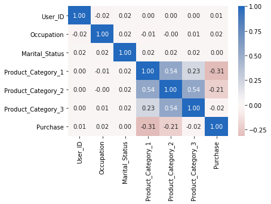

```python
sns.heatmap(df.corr(), annot = True, fmt = '.2f', cmap = 'vlag_r', center = 0)
```

```python
#Insights on NaN values
df.isnull().sum()
```

```
User_ID                            0
Product_ID                         0
Gender                             0
Age                                0
Occupation                         0
City_Category                      0
Stay_In_Current_City_Years         0
Marital_Status                     0
Product_Category_1                 0
Product_Category_2            166986
Product_Category_3            373299
Purchase                           0
dtype: int64
```

we are able to see more null values in Product_Category_2 and Product_Category_3, let us check the value counts for each category.

```python
#Let us check the values counts on product category trend
df["Product_Category_1"].value_counts()
```

```
5     148592
1     138353
8     112132
11     23960
2      23499
6      20164
3      19849
4      11567
16      9697
15      6203
13      5440
10      5032
12      3875
7       3668
18      3075
14      1500
17       567
9        404
Name: Product_Category_1, dtype: int64
```

```python
df["Product_Category_2"].value_counts()
```

```
8.0     63058
14.0    54158
2.0     48481
16.0    42602
15.0    37317
5.0     25874
4.0     25225
6.0     16251
11.0    13945
17.0    13130
13.0    10369
9.0      5591
12.0     5419
10.0     2991
3.0      2835
18.0     2730
7.0       615
Name: Product_Category_2, dtype: int64
```

```python
df["Product_Category_3"].value_counts()
```

```
16.0    32148
15.0    27611
14.0    18121
17.0    16449
5.0     16380
8.0     12384
9.0     11414
12.0     9094
13.0     5385
6.0      4818
18.0     4563
4.0      1840
11.0     1773
10.0     1698
3.0       600
Name: Product_Category_3, dtype: int64
```

```python
# Deep copy the original data frame, so that changes made in copy will not impact the original version
df_copy = df.copy()
```

```python
print ("Shape of Original df:{}".format(df.shape))
print ("Shape of Copy df_copy:{}".format(df_copy.shape))
```

```
Shape of Original df:(537577, 12)
Shape of Copy df_copy:(537577, 12)
```

Now let us drop the Nan values in the copied dataframe to see how much data loss we have

```python
df_copy.dropna(inplace=True)
```

```python
print ("Shape of Original df:{}".format(df.shape))
print ("Shape of Copy df_copy:{}".format(df_copy.shape))
```

```
Shape of Original df:(537577, 12)
Shape of Copy df_copy:(164278, 12)
```

```python
df_copy[["Product_ID","Product_Category_1","Product_Category_2","Product_Category_3"]].head()
```

|  | Product_ID | Product_Category_1 | Product_Category_2 | Product_Category_3 |
| --- | --- | --- | --- | --- |
| 1 | P00248942 | 1 | 6.0 | 14.0 |
| 6 | P00184942 | 1 | 8.0 | 17.0 |
| 13 | P00145042 | 1 | 2.0 | 5.0 |
| 14 | P00231342 | 5 | 8.0 | 14.0 |
| 16 | P0096642 | 2 | 3.0 | 4.0 |

```python
print("Shape of the original data set : {}".format(df.shape))
print("Shape of the NaN removed data set : {}".format(df_copy.shape))
```

```
Shape of the original data set : (537577, 12)
Shape of the NaN removed data set : (164278, 12)
```

```python
#df_copy.dropna().shape[0]/df_copy.shape[0]
print ("Propotion of missing values in df :{0:.2f}".format((df.shape[0] - df_copy.shape[0])/df.shape[0]))
```

```
Propotion of missing values in df :0.69
```

**Removing the NaN values is resulting in loss of 70% data in the data set**. This results in *bias-ed* model causing the model to be underfit.

The available alternate approaches are imputing the missing values with mean, mode or fill with 0. since the Product_Catgeory_2 & Product_Catgeory_3 coulmns are interlinked with values present in Product_Catgeory_1, hence imputing with mean/mode is not a good strategy, hence we will fill the Nan values with 0.

```python
#Fill na with Zero
df.fillna(0, inplace=True)
```

```python
df.isnull().sum()
```

```
User_ID                       0
Product_ID                    0
Gender                        0
Age                           0
Occupation                    0
City_Category                 0
Stay_In_Current_City_Years    0
Marital_Status                0
Product_Category_1            0
Product_Category_2            0
Product_Category_3            0
Purchase                      0
dtype: int64
```

There is no NaN values in the dataset, which is ready for further analysis now !!!